# Case Study 1

Donald Anderson

## Introduction

In this case study, I investigated “The Beers Data Set”. The data set contains a list of 2,410 US craft beers and Breweries contain 558 US breweries. I provide my recommendations to a commercial beer company regarding the top potential markets for their new beer launch based on 9 key insights derived from the data.

## Import Data

```r
beers<- read.csv(file = "Beers.csv")
Breweries<- read.csv(file = "Breweries.csv")
```

1. How many breweries are present in each state?

```r
Breweries%>%
  group_by(State)%>%
  count(name = "NoBreweries")%>%
  arrange(desc(NoBreweries))%>%
  kableExtra::kable(format = "html", padding = 0, caption = "Breweries per State")
```

Breweries per State

| State | NoBreweries |
| --- | --- |
| CO | 47 |
| CA | 39 |
| MI | 32 |
| OR | 29 |
| TX | 28 |
| PA | 25 |
| MA | 23 |
| WA | 23 |
| IN | 22 |
| WI | 20 |
| NC | 19 |
| IL | 18 |
| NY | 16 |
| VA | 16 |
| FL | 15 |
| OH | 15 |
| MN | 12 |
| AZ | 11 |
| VT | 10 |
| ME | 9 |
| MO | 9 |
| MT | 9 |
| CT | 8 |
| AK | 7 |
| GA | 7 |
| MD | 7 |
| OK | 6 |
| IA | 5 |
| ID | 5 |
| LA | 5 |
| NE | 5 |
| RI | 5 |
| HI | 4 |
| KY | 4 |
| NM | 4 |
| SC | 4 |
| UT | 4 |
| WY | 4 |
| AL | 3 |
| KS | 3 |
| NH | 3 |
| NJ | 3 |
| TN | 3 |
| AR | 2 |
| DE | 2 |
| MS | 2 |
| NV | 2 |
| DC | 1 |
| ND | 1 |
| SD | 1 |
| WV | 1 |

Colorado has the most number of breweries.

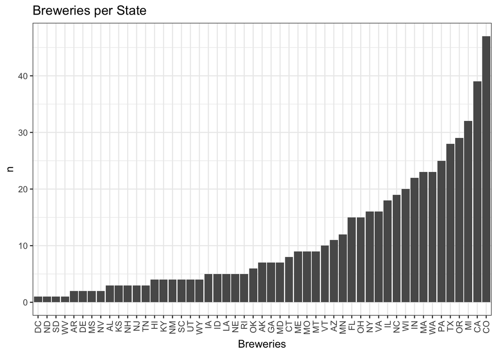

```r
kk <- Breweries%>%
  group_by(State)%>%
  summarize(n=n())

kk <- kk%>%
dplyr:: mutate(State = fct_reorder(State,n))

  ggplot(data = kk)+
   aes(y=n, x=State)+
  geom_bar(stat = "identity")+
  labs(title = "Breweries per State",
       x="Breweries")+
  theme_bw()+
   theme(axis.text.x = element_text(angle = 90, vjust = 0.5, hjust=1))
```

2. Merge beer data with the breweries data. Print the first 6 observations and the last six observations to check the merged file. (RMD only, this does not need to be included in the presentation or the deck.)

```r
merged<- left_join(beers, Breweries, by= c("Brewery_id"= "Brew_ID"))%>%
  rename("BeerName"= "Name.x", Brewery.Name="Name.y" )
head(merged, 6)%>%
  kableExtra::kable(format = "html", padding = 0)
```

| BeerName | Beer_ID | ABV | IBU | Brewery_id | Style | Ounces | Brewery.Name | City | State |
| --- | --- | --- | --- | --- | --- | --- | --- | --- | --- |
| Pub Beer | 1436 | 0.050 | NA | 409 | American Pale Lager | 12 | 10 Barrel Brewing Company | Bend | OR |
| Devil’s Cup | 2265 | 0.066 | NA | 178 | American Pale Ale (APA) | 12 | 18th Street Brewery | Gary | IN |
| Rise of the Phoenix | 2264 | 0.071 | NA | 178 | American IPA | 12 | 18th Street Brewery | Gary | IN |
| Sinister | 2263 | 0.090 | NA | 178 | American Double / Imperial IPA | 12 | 18th Street Brewery | Gary | IN |
| Sex and Candy | 2262 | 0.075 | NA | 178 | American IPA | 12 | 18th Street Brewery | Gary | IN |
| Black Exodus | 2261 | 0.077 | NA | 178 | Oatmeal Stout | 12 | 18th Street Brewery | Gary | IN |

```r
tail(merged, 6)%>%
  kableExtra::kable(format = "html", padding = 1)
```

|  | BeerName | Beer_ID | ABV | IBU | Brewery_id | Style | Ounces | Brewery.Name | City | State |
| --- | --- | --- | --- | --- | --- | --- | --- | --- | --- | --- |
| 2405 | Rocky Mountain Oyster Stout | 1035 | 0.075 | NA | 425 | American Stout | 12 | Wynkoop Brewing Company | Denver | CO |
| 2406 | Belgorado | 928 | 0.067 | 45 | 425 | Belgian IPA | 12 | Wynkoop Brewing Company | Denver | CO |
| 2407 | Rail Yard Ale | 807 | 0.052 | NA | 425 | American Amber / Red Ale | 12 | Wynkoop Brewing Company | Denver | CO |
| 2408 | B3K Black Lager | 620 | 0.055 | NA | 425 | Schwarzbier | 12 | Wynkoop Brewing Company | Denver | CO |
| 2409 | Silverback Pale Ale | 145 | 0.055 | 40 | 425 | American Pale Ale (APA) | 12 | Wynkoop Brewing Company | Denver | CO |
| 2410 | Rail Yard Ale (2009) | 84 | 0.052 | NA | 425 | American Amber / Red Ale | 12 | Wynkoop Brewing Company | Denver | CO |

The head and the tail functions show how the first 6 and the last 6 rows of the data look.

3. Address the missing values in each column.

```r
# Construct linear model based on non-NA pairs
df2 <- merged %>% filter(!is.na(IBU) , !is.na(ABV) )

fit <- lm(IBU ~ ABV, data = df2)
fit2 <- lm( ABV~IBU, data = df2)

summary(fit)
```

```
##
## Call:
## lm(formula = IBU ~ ABV, data = df2)
##
## Residuals:
##     Min      1Q  Median      3Q     Max
## -78.849 -11.977  -0.721  13.997  93.458
##
## Coefficients:
##             Estimate Std. Error t value Pr(>|t|)
## (Intercept)  -34.099      2.326  -14.66   <2e-16 ***
## ABV         1282.037     37.860   33.86   <2e-16 ***
## ---
## Signif. codes:  0 '***' 0.001 '**' 0.01 '*' 0.05 '.' 0.1 ' ' 1
##
## Residual standard error: 19.26 on 1403 degrees of freedom
## Multiple R-squared:  0.4497, Adjusted R-squared:  0.4493
## F-statistic:  1147 on 1 and 1403 DF,  p-value: < 2.2e-16
```

```r
# Use fit to predict the value
df3 <- merged %>%
  mutate(pred = predict(fit, .),
         pred2= predict(fit2, .) ) %>%
  # Replace NA with pred in var1
  mutate(IBU = ifelse(is.na(IBU), pred, IBU),
         ABV = ifelse(is.na(ABV), pred, ABV),
         pred= NULL,
         pred2= NULL)%>%
  drop_na()
```

To deal with missing values in ABV and IBU variables we used linear regression to predict the missing data. In cases where the values were not predictable, that is where both ABV an IBU were missing, the rows were removed form the data set.

4. Compute the median alcohol content and international bitterness unit for each state. Plot a bar chart to compare.

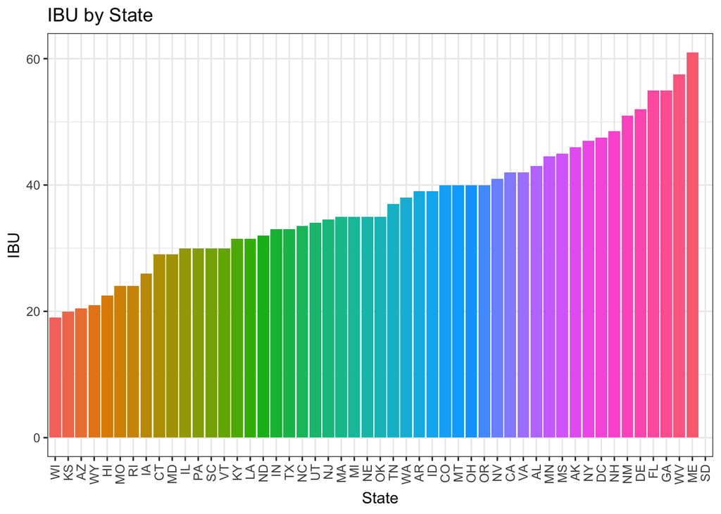

```r
mediandf<-merged%>%
  group_by(State)%>%
  summarise(IBU= median(IBU, na.rm = T), ABV= median(ABV, na.rm = T))%>%
  mutate(State = fct_reorder(State, IBU))

ggplot(data = mediandf, aes(y=IBU, x= State, fill= State))+
  geom_bar(stat = "identity", show.legend = F)+
  labs(title = "IBU by State")+
  theme_bw()+
  theme(axis.text.x = element_text(angle = 90, vjust = 0.5, hjust=1))
```

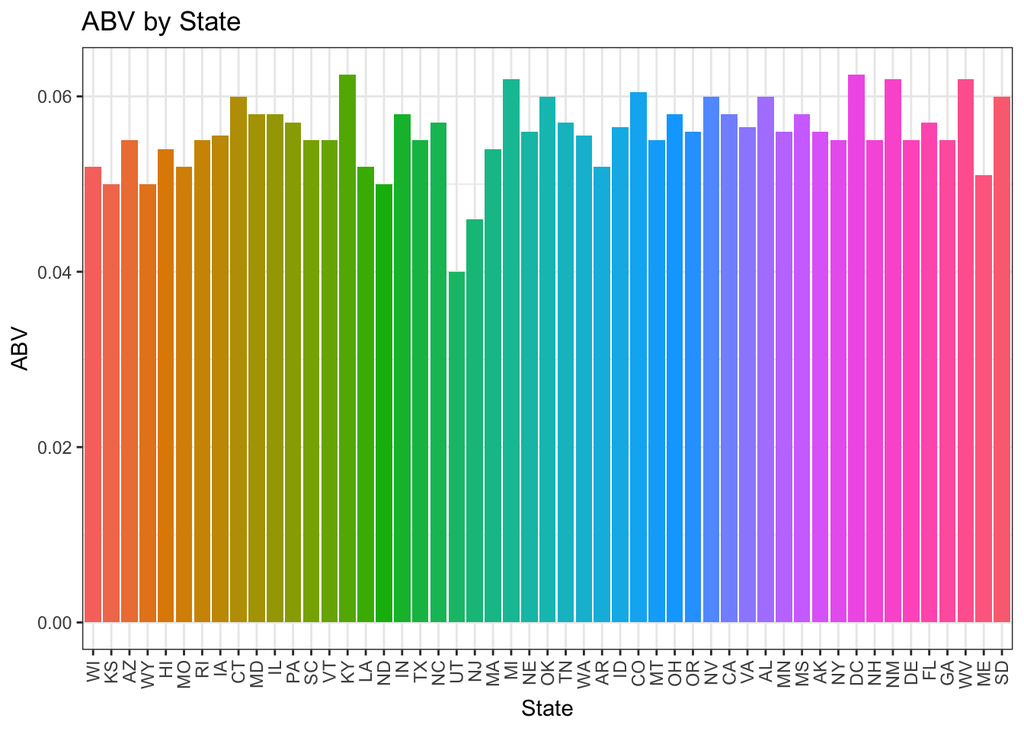

```r
ggplot(data = mediandf, aes(y=ABV, x= State, fill= State))+
  geom_bar(stat = "identity", show.legend = F)+
  labs(title = "ABV by State")+
  theme_bw()+
  theme(axis.text.x = element_text(angle = 90, vjust = 0.5, hjust=1))
```

Note: Removed 1 row containing missing values (position_stack) from the IBU bar chart.

5. Which state has the maximum alcoholic (ABV) beer? Which state has the most bitter (IBU) beer?

```r
maxdf<-df3%>%
  group_by(State)%>%
  summarise(IBU= mean(IBU), ABV= mean(ABV))

merged$State[which.max(merged$ABV)]
```

```
## [1] " CO"
```

```r
merged$State[which.max(merged$IBU)]
```

```
## [1] " OR"
```

Colorado state has the maximum alcoholic (ABV) beer while Oregon state has the most bitter beers.

6. Comment on the summary statistics and distribution of the ABV variable.

```r
psych::describe(df3$ABV)%>%
  kableExtra::kable(format = "html", padding = 1)
```

|  | vars | n | mean | sd | median | trimmed | mad | min | max | range | skew | kurtosis | se |
| --- | --- | --- | --- | --- | --- | --- | --- | --- | --- | --- | --- | --- | --- |
| X1 | 1 | 2348 | 0.0597734 | 0.0135417 | 0.056 | 0.0583888 | 0.0118608 | 0.001 | 0.128 | 0.127 | 0.9572529 | 1.13642 | 0.0002795 |

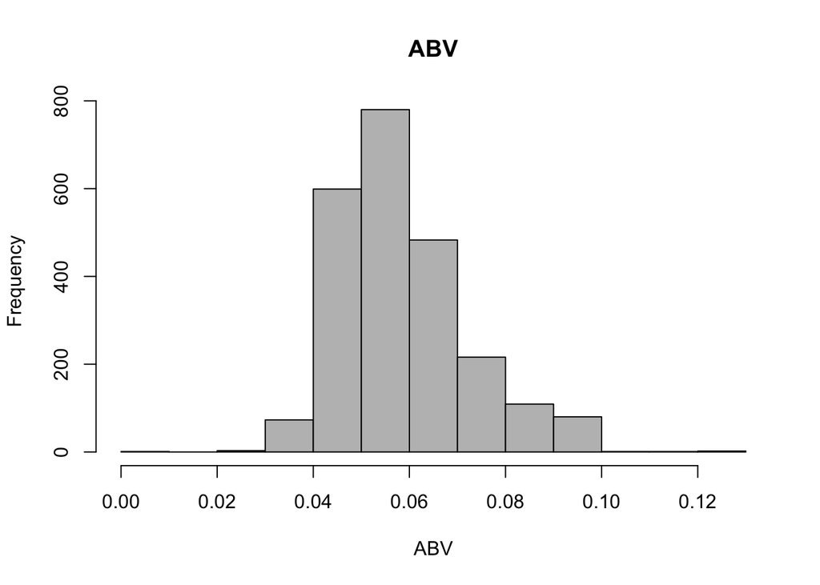

```r
hist(df3$ABV, breaks = 10, main = "ABV", xlab = "ABV", col = "gray")
```

Alcohol by volume of the beer has a mean of 0.06 with a standard deviation of 0.01. The histogram shows that the data is slightly skewed to the right, in other words the data is positively skewed.

7. Is there an apparent relationship between the bitterness of the beer and its alcoholic content? Draw a scatter plot. Make your best judgment of a relationship and EXPLAIN your answer.

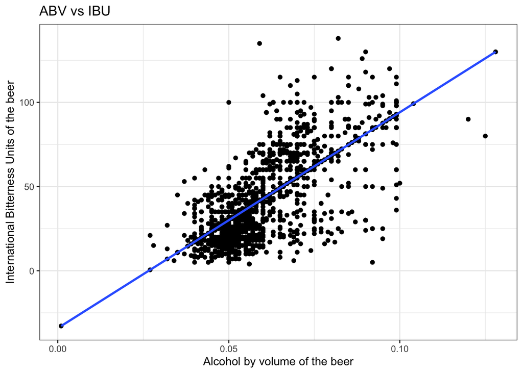

```r
ggplot(data = df3, aes(x= ABV, y=IBU))+
  geom_point()+
  geom_smooth(se=F, method = "lm")+
  labs(title = "ABV vs IBU",
       y="International Bitterness Units of the beer",
       x= "Alcohol by volume of the beer")+
  theme_bw()
```

8. Budweiser would also like to investigate the difference with respect to IBU and ABV between IPAs (India Pale Ales) and other types of Ale (any beer with “Ale” in its name other than IPA). You decide to use KNN classification to investigate this relationship. Provide statistical evidence one way or the other. You can of course assume your audience is comfortable with percentages … KNN is very easy to understand conceptually.

```r
#
KNNDF<- df3%>%
  filter(grepl(" Ale ", Style, ignore.case = T) | grepl("Ipa", df3$Style, ignore.case = T))%>%
  mutate(type= case_when( grepl("Ipa", Style, ignore.case = T)~"Ipa",
                          TRUE~ "Ale"))%>%
  select(ABV,IBU,type)

set.seed(300)
#Splitting data as training and test set. Using createDataPartition() function from caret
indxTrain <- createDataPartition(y = KNNDF$type,p = 0.75,list = FALSE)
training <- KNNDF[indxTrain,]
testing <- KNNDF[-indxTrain,]


set.seed(400)
ctrl <- trainControl(method="repeatedcv",repeats = 10)
#,classProbs=TRUE,summaryFunction = twoClassSummary)
knnFit <- train(type ~ ., data = training, method = "knn",
                trControl = ctrl, preProcess = c("center","scale"), tuneLength = 20)

#Output of kNN fit
knnFit
```

```
## k-Nearest Neighbors
##
## 611 samples
##   2 predictor
##   2 classes: 'Ale', 'Ipa'
##
## Pre-processing: centered (2), scaled (2)
## Resampling: Cross-Validated (10 fold, repeated 10 times)
## Summary of sample sizes: 550, 550, 550, 550, 550, 550, ...
## Resampling results across tuning parameters:
##
##   k   Accuracy   Kappa
##    5  0.8274987  0.6031948
##    7  0.8284691  0.6037750
##    9  0.8235431  0.5890908
##   11  0.8258250  0.5922936
##   13  0.8196087  0.5747189
##   15  0.8241962  0.5872754
##   17  0.8287731  0.5974090
##   19  0.8258329  0.5900467
##   21  0.8241909  0.5826191
##   23  0.8210973  0.5695296
##   25  0.8229059  0.5722713
##   27  0.8232232  0.5738801
##   29  0.8229032  0.5742170
##   31  0.8224167  0.5738847
##   33  0.8220809  0.5740062
##   35  0.8214305  0.5735497
##   37  0.8219143  0.5765143
##   39  0.8237176  0.5823097
##   41  0.8229059  0.5811887
##   43  0.8269937  0.5910321
##
## Accuracy was used to select the optimal model using the largest value.
## The final value used for the model was k = 17.
```

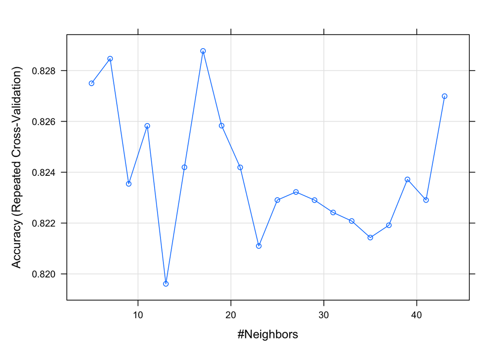

```r
#Plotting yields Number of Neighbors Vs Accuracy (based on repeated cross validation)
plot(knnFit)
```

```r
knnPredict <- predict(knnFit,newdata = testing )
#Get the confusion matrix to see accuracy value and other parameter values
confusionMatrix(knnPredict, factor(testing$type))
```

```
## Confusion Matrix and Statistics
##
##           Reference
## Prediction Ale Ipa
##        Ale  50  15
##        Ipa  13 125
##
##                Accuracy : 0.8621
##                  95% CI : (0.8069, 0.9063)
##     No Information Rate : 0.6897
##     P-Value [Acc > NIR] : 9.876e-09
##
##                   Kappa : 0.6806
##
##  Mcnemar's Test P-Value : 0.8501
##
##             Sensitivity : 0.7937
##             Specificity : 0.8929
##          Pos Pred Value : 0.7692
##          Neg Pred Value : 0.9058
##              Prevalence : 0.3103
##          Detection Rate : 0.2463
##    Detection Prevalence : 0.3202
##       Balanced Accuracy : 0.8433
##
##        'Positive' Class : Ale
##
```

```r
mean(knnPredict == testing$type)
```

```
## [1] 0.862069
```

9. Knock their socks off! Find one other useful inference from the data that you feel Budweiser may be able to find value in. You must convince them why it is important and back up your conviction with appropriate statistical evidence.

```r
#diffrence in meant
t.test( ABV~type, data = KNNDF)
```

```
##
##  Welch Two Sample t-test
##
## data:  ABV by type
## t = -17.318, df = 688.65, p-value < 2.2e-16
## alternative hypothesis: true difference in means between group Ale and group Ipa is not equal to 0
## 95 percent confidence interval:
##  -0.01440100 -0.01146818
## sample estimates:
## mean in group Ale mean in group Ipa
##        0.05585827        0.06879286
```

There is a claim that there is no difference in ABV mean between IPA and Ale beer type. The t-test shows a p-value less than 0.05 significance level. There we reject the null hypothesis and conclude that indeed there is a difference in ABV mean of IPA and Ale beer type.

## Conclusion.

Colorado is the leading state in number of breweries. ABV and IBU have a positive correlation. There are both important variables in predicting the type of beer. Finally, some beers have higher ABV than others.